# Conceitos

O primeiro passo para entender do que se trata os Campos Elétricos, iremos definir alguns conceitos fundamentais.

# Cargas elétricas

(Considerando cargas elétricas pontuais)

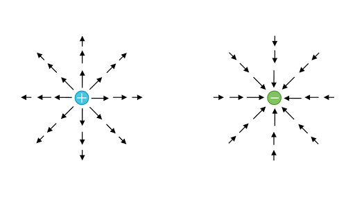

**O que é uma carga pontual?** **Uma carga pontual gera campo elétrico?** **O que difere uma carga elétrica positiva de uma carga elétrica negativa?**

Define-se carga elétrica pontual sendo um corpo eletrizado cujas dimensões são desprezíveis se comparadas às distâncias que o separam de outros corpos eletrizados.

O campo elétrico de uma carga pontual terá direção radial, ou seja, como se a carga estivesse localizada no centro de um círculo de raio “r”.

$~$

## Natureza das cargas elétricas

Cargas elétricas podem apresentar natureza positiva ou negativa.

Uma das principais diferenças entre as cargas positivas e negativas são as linhas de campos geradas por essas cargas uma vez que o sentido de F é para longe da carga pontual q se ela for positiva e na direção da carga pontual se q for negativa.

Observe a imagem a seguir para visualizar o campo elétrico gerado por cada uma dessas cargas.

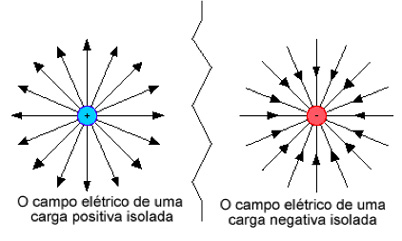

$~$

## Como determinar um campo elétrico?

(a partir dessas cargas pontuais)

Para determinar o campo elétrico produzido por uma distância r de uma carga pontual q, colocamos uma carga de prova qo nesse ponto.

De acordo com a **Lei de Coulomb**, o módulo da força eletrostática que age sobre qo é dado por:

Definindo a Lei de Coulumb:

$$\vec{F_e}=k_{e}{\frac {qq_{0}}{r^{2}}}\hat{\mathbf r}$$

Constante de Permissividade Elétrica:

$$k_e = \frac{1}{{4\pi \varepsilon _0 }} \\$$

$k_e$ ≈ 8.988 x $10^9 N {m^2}/{C^2}$

$~$

# Campo elétrico

**O que é um campo elétrico?** **Qual é o limite de um campo elétrico?**

Cargas elétricas modificam as propriedades elétricas do espaço à sua volta, causando um campo elétrico. Esse campo elétrico desempenha a função de transmissor das interações entre cargas elétricas, podendo ser de afastamento ou de aproximação, de acordo com o sinal da carga que o produziu, sendo ele uma grandeza vetorial que depende do ponto no espaço em que ela se encontra.

$~$

## Fórmula Matemática

**Como calcular matemáticamento um campo elétrico?**

A expressão abaixo nos permite calcular a intensidade do campo elétrico, quaisquer que sejam as cargas que criam esse campo.

Definindo Campo Elétrico a partir de Força Elétrica:

$${\vec{E_i}}= \frac{\vec{F_e}} {q_0}$$

Para encontrarmos o módulo do vetor campo elétrico de uma carga pontual é dado por:

$${\vec{E_i}}= \frac{\vec{F_e}} {q_0} = \frac{1}{q_0} \frac{1}{4\pi\varepsilon_0} \frac{qq_{0}}{r^{2}} \hat{\mathbf r} = \frac{1}{{4\pi\varepsilon _0}} \frac{q}{r^{2}} \hat{\mathbf r}$$

$${\vec{E_i}}= \frac{1}{{4\pi\varepsilon _0}} \frac{q}{r^{2}} \hat{\mathbf r}$$
$~$

## Simulação

Na simulação abaixo é possível adicionar cargas positivas (vermelhas) e negativas (azuis) e verificar o comportamento dos campos elétricos gerados por elas. Aplicando um sensor (ponto amarelo), é possível visualizar o vetor diretor desse campo em vários pontos da tela, conforme reposicionar o curso. Ainda é possível verificar o potencial desse campo e a distância entre as cargas, posicionando os equipamentos localizados na parte direta inferior.

Que tal adicionar uma carga positiva e uma negativa? Esse cenário cria um dipolo elétrico!

[interactive chart not shown]

$~$

# Campo elétrico Total

**Como o campo elétrico gerado por uma carga pontual interfere no campo elétrico gerado por uma outra carga pontual?** **Qual será relação da natureza das cargas nesse sentido?**

O sentido do campo elétrico é o mesmo que o da força que age sobre a carga, ou seja, cargas de mesma natureza ou mesmo sinal quando estão próximas tem um comportamento de repulsão entre si. Já cargas de sinais opostos estão próximas sua tendência é se aproximar ainda mais, logo o sentido do campo elétrico será para longe da carga pontual positiva e na direção da carga pontual negativa.

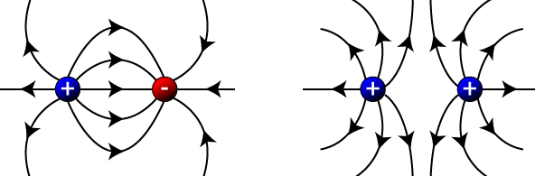

$~$

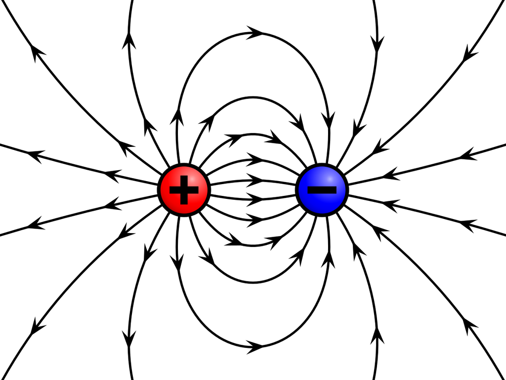

$~$

Quando colocamos uma carga prova positiva $q_0$ nas proximidades de N cargas pontuais $q_1$, $q_2$,…$q_n$, a carga de prova é submetida a uma força total $\vec{F_T}$ dada por:

$$\vec{F_T} = \vec{F_1} + \vec{F_2} + ... + \vec{F_n}$$

$$\vec{F_T} = \sum_{i}^{n}\vec{F_i}$$

Assim, o campo elétrico total $\vec{E_T}$ na posição da carga de prova é dado por:

$$\vec{E_T} = \frac{\vec{F_T}}{q_0} = \frac{\vec{F_1}}{q_0} + \frac{\vec{F_2}}{q_0} + ... + \frac{\vec{F_n}}{q_0}$$

$$\vec{E_T} = \vec{E_1} + \vec{E_2} + ... + \vec{E_n} = \sum_{i}^{n}\vec{E_i}$$

Em que E1 é o campo elétrico que seria criado somente pela carga pontual 1. A equação mostra que o princípio de superposição se aplica aos campos elétricos.

$~$

# Dipolo elétrico

**Campo elétrico produzido por dipolo elétrico**

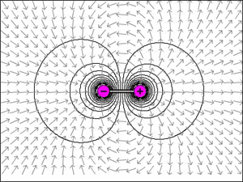

$~$

Duas partículas carregadas de módulo q e sinais opostos, separadas por uma distância d recebem o nome de dipolo elétrico.

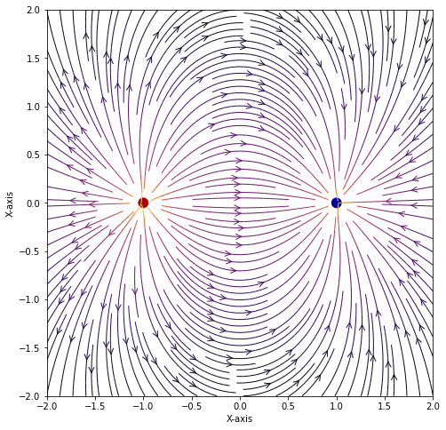

$~$

## Curiosidade!

Instruções para aumentar o número de Cargas

1. É só aumentar as Potências de 2 (linha 27)
- Para uma Carga pontual -> nq = 2**0
- Para uma Carga dipolo -> nq = 2**1
- Para uma Carga multipolo -> nq = 2**2
- E assim por diante! Divirta-se!
- E espere o gráfico ser plotado, pois demora um pouco para gerar a imagem.
2. Não se esqueça de rodar o código clicando na seta (Run)

[interactive chart not shown]

$~$

# Referências

1. HALLIDAY, David, RESNICK, Robert, WALKER, Jearl. Fundamentos de Física - Vol. 3 - Eletromagnetismo, 10ª edição. LTC, 06/2016. VitalBook file.
2. PERKINS, Kathy.PAUL, Ariel. University of Colorado Boulder. Cargas e Campos - versão 1.048. Disponível em: https://phet.colorado.edu/sims/html/charges-and-fields/latest/charges-and-fields_pt_BR.html. Acesso em: 05 de janeiro de 2021.
3. GEEKS FOR GEEKS. Matplotlib.pyplot.streamplot() in Python. Publicado em 12/04/2020. Disponível em: https://www.geeksforgeeks.org/matplotlib-pyplot-streamplot-in-python/. Acesso em: 04 de janeiro de 2021.